# Visa to France - 2: Everything for the Visa appointment at the French Embassy

The French Embassy may ask for a lot of documents

french bureaucracy

going to France

Published

September 21, 2021

# Tip

Here’s something I wish I new:

> You can reserve an appointment at the French embassy independently of the status of your Campus France process (at least in my country.)

Because there was the pandemic, the queue at the French Embassy was huge, so one could only get appointments for two or three months in the future. Since I waited until I had my Campus France certificate (*Accord préalable*), the process took longer for me.

Of course, when you actually show up, you need to have all the documents for the Visa application.

# Starting the online application

The Visa Application platform can be found in [France-Visas](https://france-visas.gouv.fr/), a French government website. **It is the same platform for all countries and all types of Visa**

I must admit that using the platform is very straightforward, and it allows you to partially fill your application and return later to complete it.

I will let them explain how to use it:

- Step 1

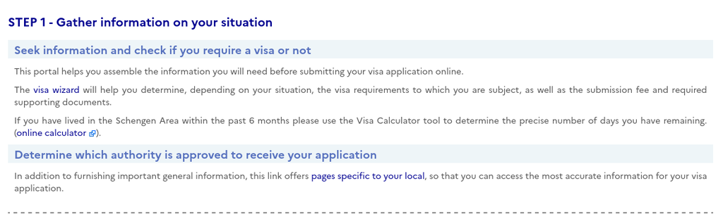

- Step 2

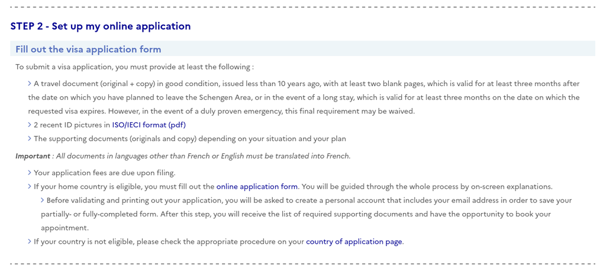

Read again:

> Important : All documents in languages other than French or English must be translated into French.

In my case, the supporting documents where:

- The admission letter to the Université de Lorraine
- The Erasmus Mundus scholarship letter
- The proof of insurance given by the LCT Master
- Campus France Certificate/ *Acoord préalable*

# Getting an appointment

Each French Embassy in each country has a different method for booking appointments. Check the [Country of application page](https://france-visas.gouv.fr/web/france-visas/lieu-de-residence?caller=depotVisas)

As I mentioned, due to the pandemic the appointments where given for two or three months into the future. First, I got an appointment that was going to be two months into the future, then, by checking the platform of the French Embassy in my country every day, I got to book an appointment one month and a half into the future (maybe someone else cancelled?).

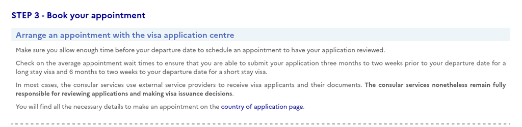

# Finishing the online application

After getting a date for the appointment, you have to log in again to the Visa Application platform, go to the step where you left your application, and check on `I already have an appointment` (or something like that).

Then, you will get a list of all the documents you need to take to the French Embassy.

# Necessary documents

These are the documents the French Embassy *in my country* told me to get for my Visa appointment:

- The Visa Application From from the platform.
- Passport
- Photocopy of your complete passport (even the empty pages!) in color.
- Campus France Certificate / *Accord Préalable d’inscription*
- ID Photo **in european (biometric) format**. (I got mine done at a Photograpy studio for around 10 USD. They already knew what I meant.)
- Proof of residence, for those who are applying in a country different than their country of nationality. (Not my case)
- Proof of resources: The scholarship letter.
  - Note that Erasmus students don’t have to pay for the Visa application! (For France, it would have been **100 €** in my country)
- Proof of insurance valid in France: the LCT program provided insurance. (This is *not* the same as travel insurance!)
- Proof of accomodation: See below

## Proof of accomodation

To get a Visa, the French Embassy needs to know that you will have a place to stay.

So, how to get this? I found out about three ways to go about this.

### Option 1: Letter from the Coordinator

This is by far **the easiest** way of getting something that you can give to the French Embassy. I didn’t know about it until after my Visa appointment and I really wish I had.

Basically, you ask the LCT Local Coordinator in France to write a letter, or to modify the Admission Letter to the University of Lorraine, saying that they promise to get you accomodation.

### Option 2: Promising you will look for accomodation

This is the option *I* took.

Basically, one writes a letter *in French* to the Consul at the French Embassy saying that you’ll be at a specific place while you wait for your definitive residence.

I booked a room at a hotel in Nancy for two weeks at booking.com, with free cancellation. After I got my Visa, I cancelled the reservation.

Before reading the letter, note: - “CROUS” is the name of the French insitution in charge of Student Residences. More to be explained in a future post. - I only booked for two weeks because that was the longest period the website allowed. - I printed and attached the booking confirmation to my dossier.

My letter to the French consul was:

```python
"""
<My name>
<My address>
<My City>

Le <Date>

Objet : lettre explicative concernant les conditions de mon hébergement en France
les trois premiers mois de mon séjour.

Monsieur le consul,

Je prends la liberté de vous fournir quelques explications relatives à mes
conditions d’hébergement en France durant les trois premiers mois de mon séjour.

Durant cette période, je serai hébergé à l’hôtel <Name of the hotel> se trouvant
à l’adresse suivante <Address of the hotel> et dont le numéro de téléphone est
<telephone number of the hotel>, le temps de me voir attribuer une chambre dans
une résidence universitaire par l’intermédiaire du CROUS.  Dans l’hypothèse où
j’obtiendrais une réponse négative de la part du CROUS, je me mettrai à la
recherche d’un appartement à louer dans le secteur privé, en passant par une
agence immobilière ou un site de petites annonces et ce en utilisant mes moyens
financiers personnels.

Je joins à la présente ma réservation d’hôtel. Même si maintenant ma réservation
est pour deux semaines, dans l’hypothèse où j’obtiendrais une réponse négative
de la part du CROUS, je le prolongerais de trois mois.

Je vous prie d’agréer, Monsieur le Consul général, l’expression de ma
respectueuse considération.



<Signature>
__________________________

""";
```

A translation (Remember the letter *must* be sent in French!) would be along the lines of:

```python
"""
<My name>
<My address>
<My City>

On the <Date>

Subject: Explanation letter regarding the conditions of my accomodation in Frence
during the first three months of my stay

Mr. consul,

I am taking the liberty of providing you some explanations concerning my accomodation
conditions in France during the first three months of my stay.

During this period, I will be lodged at the hotel <Name of the hotel> which can be
found at the following address <Address of the hotel> and whose phone number is
<telephone number of the hotel> during the time that it takes for me to receive a
room at a student residence via the itermediary CROUS. In the case where I were to
obtain a negative response from CROUS, I will start searching for an accomodation to
rent on the private sector, either through an immobiliary agency or through a renting
website, using my personal financial means.

I attach to this letter my hotel reservation. Even if now my reservation is only for
two weeks, in the case where I were to obtain a negative response from CROUS,
I will extend it for three months.

I ask you to accept, Mr General Consul, my respectful greetings

<Signature>
__________________________

""";
```

### Option 3: Proof of acceptance into a Student Residence

This **is a nightmare**.

You will find online that this is the standard procedure for getting a proof of accomodation. It is very long and convoluted, you *will* have to do it at some point so that you actually get into a Student Residence, but it is possible to apply for the visa without it (see Options 1 and 2 above).

This issue will have it’s own post, but in summary, there is a bureacractic loophole that makes going through the standard process of applying to a student residence very difficult for those who are not already residing in France.

All the LCT Students of my batch tried to do it for months, but we gave up. Ultimately most went for Option 1.

In my case, I tried to get to use this option unsuccessfully, and while searching online for alternatives, I found out about Option 2 in an official website of the French Government. That’s why I went for Option 2. If I had known Erasmus Mundus students had Option 1 available, I would have used that one.

# The appointment at the French embassy

> **Be on time**

The French Embassy in my country had very unconvenient opening hours: - They only took visa applications for one hour and a half each day, only during the mornings. - They had not updated their opening hours on their website, luckily I got early enough so that this was not a problem.

The appointment itself was very smothly…. until I realised I had forgotten to print one document and had to run to a printing shop for it. Luckily, since I had the earliest appointment, when I returned I was still on time to leave the missing document.

[figure not shown]

They checked all my documents and took them in. Then they waved the Visa application fee because I was an Erasmus student.

Finally, I was told to wait at least one month for the answer and received a ticket to pick up my passport.

You can track your application on the Visa Application platform!

# The final answer

It took the French Embassy around **six weeks** to get back to me with the final answer.

> I got it!

[figure not shown]

Important to note:

> **My Visa had a validity of one year from August 2021 to July 2022.**

and,

> **I got the French Visa on July 2021, one month and a half before leaving to France**

finally,

> This was the end of my interaction with the French Embassy in my country.

*Again, note that requirements vary by country and that many things were different due to the pandemic*